# Sierra Leone COVID-19 Dashboard

Tracking Economic Consequences and Responses to COVID-19 in Sierra Leone

Continuous access to information on key economic indicators is essential to help Sierra Leone respond to the Covid-19 pandemic.

This dashboard provides real time data on current economic conditions and trends from a phone based survey being rolled out in 195 towns and villages across Sierra Leone.[^1]

## Current cases

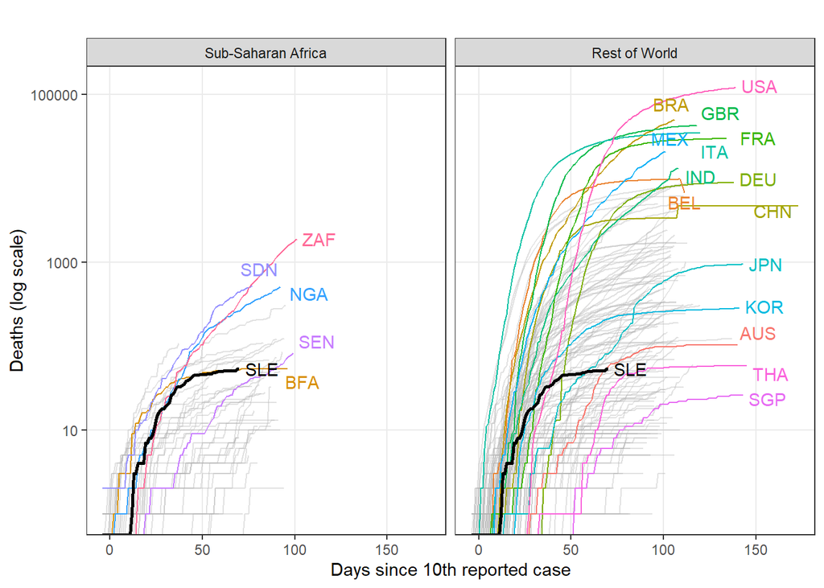

**Source**: Figures draw from the European Centre for Disease Prevention and Control

## markets

### Time trends

#### National aggregates

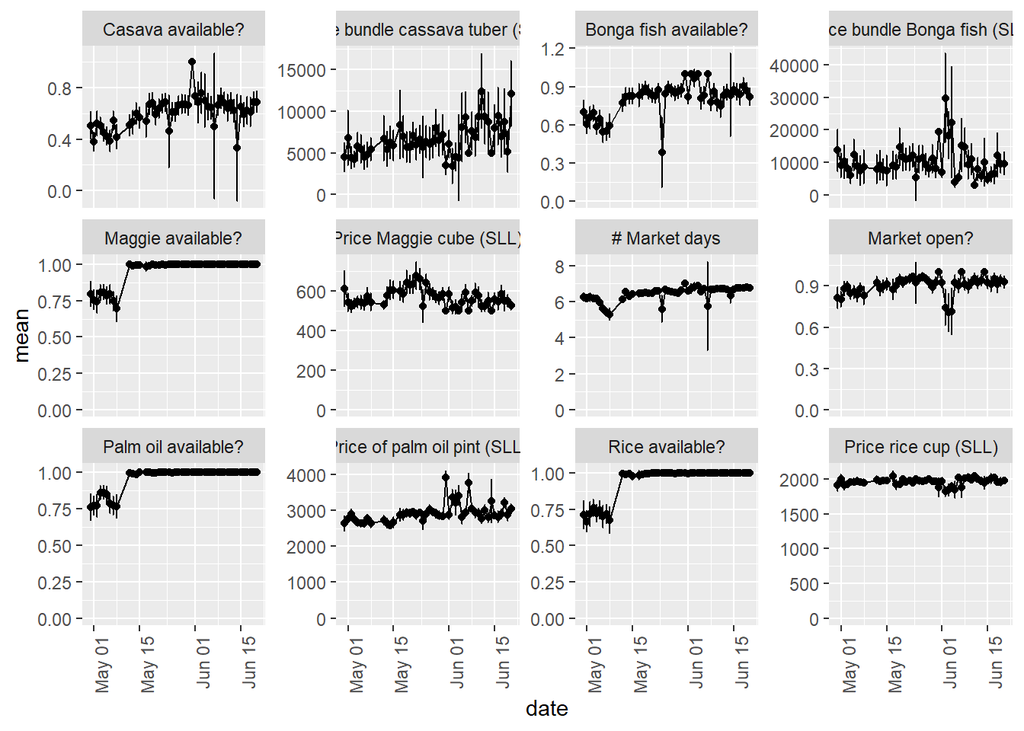

Average responses for a given day (dot) with 95% confidence intervals (whiskers)

#### Broken down by District

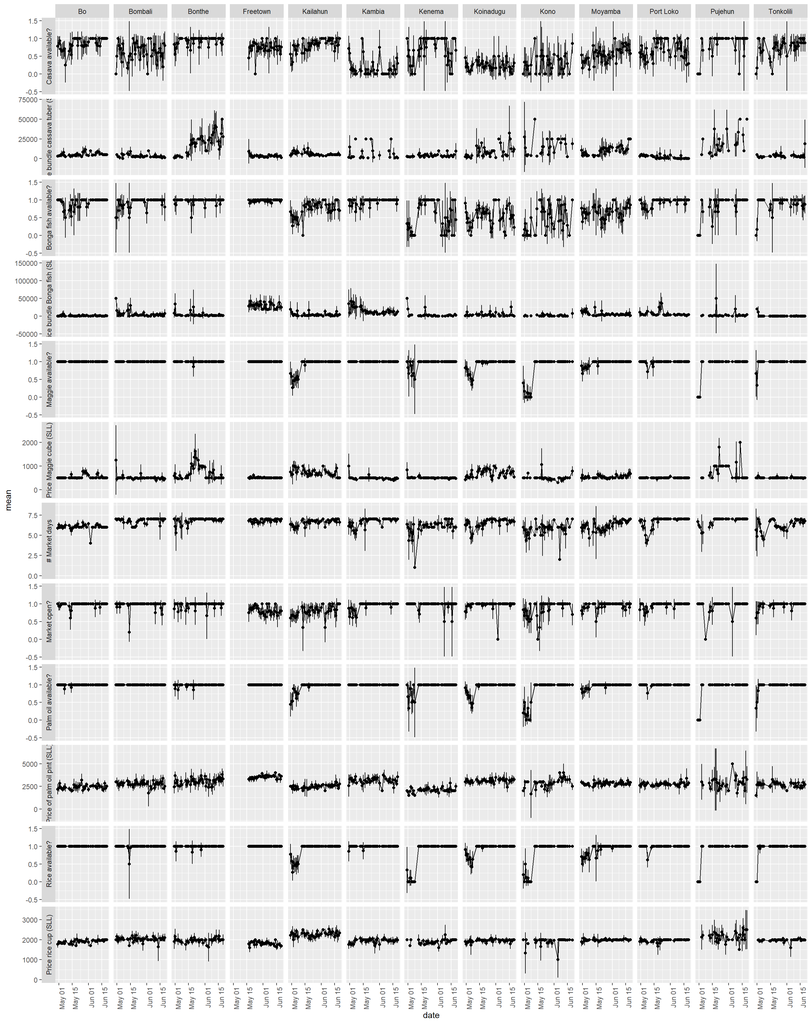

Disaggregated average responses for a given day (dot) with 95% confidence intervals (whiskers)

### Current averages

Mean responses in each District (most recent date)

| District | Date | Market open? | # Market days | Rice available? | Casava available? | Bonga fish available? | Palm oil available? | Maggie available? | Price rice cup (SLL) | Price bundle cassava tuber (SLL) | Price bundle Bonga fish (SLL) | Price of palm oil pint (SLL) | Price Maggie cube (SLL) |
| --- | --- | --- | --- | --- | --- | --- | --- | --- | --- | --- | --- | --- | --- |
| Bo | 2020-05-21 | 0.97 | 6.10 | 1.00 | 0.82 | 0.92 | 0.99 | 1.00 | 1891.01 | 5679.18 | 1645.37 | 2382.15 | 560.32 |
| Bombali | 2020-05-23 | 0.95 | 6.74 | 0.99 | 0.62 | 0.91 | 1.00 | 1.00 | 2026.55 | 3545.53 | 7273.46 | 2785.34 | 502.02 |
| Bonthe | 2020-05-23 | 0.96 | 6.74 | 0.99 | 0.93 | 0.97 | 0.99 | 1.00 | 1961.04 | 18586.81 | 4083.83 | 3040.86 | 717.13 |
| Freetown | 2020-06-02 | 0.80 | 6.75 | 1.00 | 0.74 | 0.98 | 1.00 | 1.00 | 1803.82 | 3190.68 | 31241.00 | 3505.64 | 509.69 |
| Kailahun | 2020-05-20 | 0.77 | 6.51 | 0.86 | 0.79 | 0.73 | 0.92 | 0.86 | 2248.43 | 6593.12 | 4634.20 | 2465.41 | 705.93 |
| Kambia | 2020-05-21 | 0.91 | 6.61 | 0.99 | 0.17 | 0.95 | 1.00 | 1.00 | 1921.49 | 7116.15 | 16843.39 | 3148.74 | 492.70 |
| Kenema | 2020-05-22 | 0.96 | 6.03 | 0.76 | 0.65 | 0.57 | 0.93 | 0.96 | 1881.40 | 4113.51 | 3319.19 | 2123.71 | 504.14 |
| Koinadugu | 2020-05-21 | 0.97 | 6.39 | 0.88 | 0.23 | 0.52 | 0.89 | 0.88 | 1939.99 | 8369.76 | 4367.26 | 3113.43 | 717.40 |
| Kono | 2020-05-22 | 0.84 | 5.81 | 0.73 | 0.30 | 0.43 | 0.75 | 0.73 | 1917.45 | 15818.18 | 2515.99 | 2928.10 | 489.92 |
| Moyamba | 2020-05-21 | 0.95 | 6.18 | 0.89 | 0.50 | 0.65 | 0.95 | 0.94 | 1979.96 | 10165.95 | 8929.59 | 2802.69 | 531.45 |
| Port Loko | 2020-05-20 | 0.94 | 6.42 | 0.98 | 0.66 | 0.90 | 0.99 | 0.98 | 1955.37 | 2166.33 | 7733.63 | 2729.06 | 501.59 |
| Pujehun | 2020-05-21 | 0.95 | 6.61 | 0.86 | 0.77 | 0.77 | 0.86 | 0.86 | 2205.83 | 19700.00 | 3713.69 | 2808.41 | 777.78 |
| Tonkolili | 2020-05-24 | 0.96 | 6.31 | 0.97 | 0.73 | 0.92 | 0.98 | 0.99 | 1961.55 | 3378.08 | 588.07 | 2680.98 | 503.86 |

### Maps

Showing most recent data available for each District.

Each map shows the *relative position* of each District — a score of 0 means average, and a score of 2 or -2 means far above or below average.

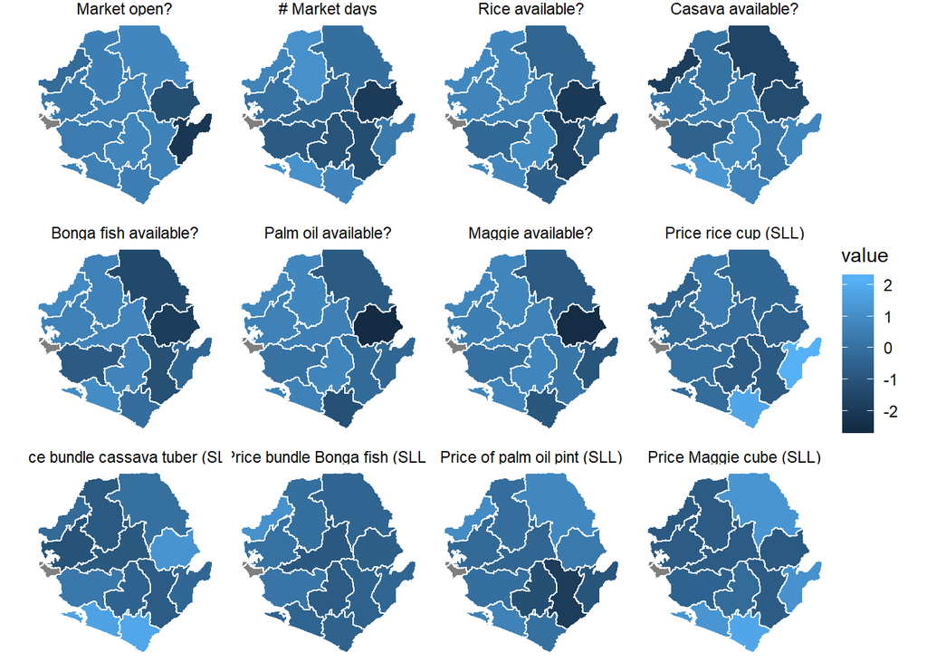

Distribution of standardized variables

### Definitions of measures

Data definitions

| Measure | Definition | Range |
| --- | --- | --- |
| Market open? | Share of respondents reporting that local market is open | 0 - 1 |
| # Market days | Days of past 7 market was open | 0 - 7 |
| Rice available? | Share of respondents reporting that rice is available in markets during past 7 days | 0 - 1 |
| Casava available? | Share of respondents reporting that cassava is available in markets during past 7 days | 0 - 1 |
| Bonga fish available? | Share of respondents reporting that Bonga fish is available in markets during past 7 days | 0 - 1 |
| Palm oil available? | Share of respondents reporting that palm oil is available in markets during past 7 days | 0 - 1 |
| Maggie available? | Share of respondents reporting that maggie is available in markets during past 7 days | 0 - 1 |
| Price rice cup (SLL) | Average price paid for a cup of rice (SLL, winsorized) | 0 - NA |
| Price bundle cassava tuber (SLL) | Average price paid for a bundle of cassava tubers (SLL, winsorized) | NA - NA |
| Price bundle Bonga fish (SLL) | Average price paid for a bundle of Bonga fish (SLL, winsorized) | 0 - NA |
| Price of palm oil pint (SLL) | Average price paid for palm oil pint (SLL, winsorized) | 0 - NA |
| Price Maggie cube (SLL) | Average price paid for Maggie cube (SLL, winsorized) | 0 - NA |

## food security

### Time trends

#### National aggregates

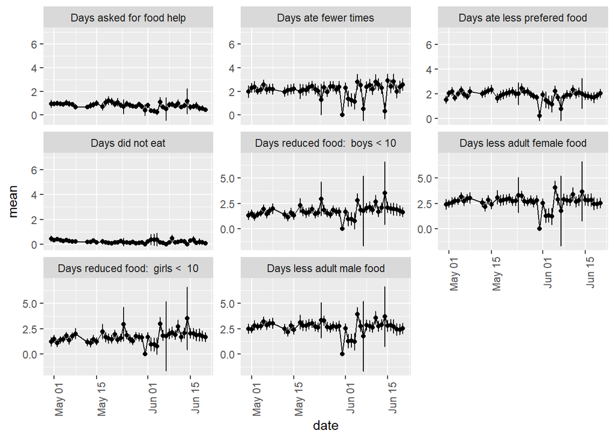

Average responses for a given day (dot) with 95% confidence intervals (whiskers)

#### Broken down by District

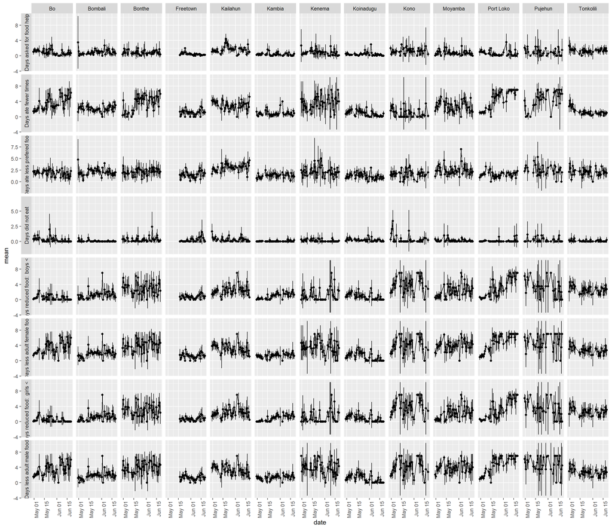

Disaggregated average responses for a given day (dot) with 95% confidence intervals (whiskers)

### Current averages

Mean responses in each District (most recent date)

| District | Date | Days ate less prefered food | Days asked for food help | Days less adult male food | Days less adult female food | Days reduced food: boys < 10 | Days reduced food: girls < 10 | Days ate fewer times | Days did not eat |
| --- | --- | --- | --- | --- | --- | --- | --- | --- | --- |
| Bo | 2020-05-21 | 1.90 | 0.96 | 2.98 | 2.95 | 0.55 | 0.49 | 2.95 | 0.32 |
| Bombali | 2020-05-23 | 2.00 | 0.88 | 1.81 | 1.85 | 1.14 | 1.10 | 2.13 | 0.08 |
| Bonthe | 2020-05-23 | 2.14 | 0.83 | 3.80 | 3.78 | 2.81 | 2.79 | 3.22 | 0.32 |
| Freetown | 2020-06-02 | 1.60 | 0.46 | 1.36 | 1.39 | 0.80 | 0.74 | 1.20 | 0.21 |
| Kailahun | 2020-05-20 | 2.97 | 1.69 | 3.45 | 3.33 | 2.26 | 2.22 | 3.27 | 0.35 |
| Kambia | 2020-05-21 | 1.23 | 0.37 | 1.32 | 1.31 | 0.87 | 0.82 | 0.81 | 0.04 |
| Kenema | 2020-05-22 | 2.10 | 0.88 | 3.85 | 3.50 | 1.25 | 1.19 | 3.23 | 0.16 |
| Koinadugu | 2020-05-21 | 1.28 | 0.36 | 1.31 | 1.32 | 0.96 | 0.95 | 1.09 | 0.23 |
| Kono | 2020-05-22 | 1.70 | 1.14 | 3.81 | 3.86 | 3.77 | 3.73 | 1.03 | 0.42 |
| Moyamba | 2020-05-21 | 2.44 | 0.77 | 3.68 | 3.85 | 1.88 | 1.76 | 2.80 | 0.13 |
| Port Loko | 2020-05-20 | 1.69 | 0.68 | 4.16 | 4.19 | 2.52 | 2.46 | 3.89 | 0.08 |
| Pujehun | 2020-05-21 | 2.64 | 1.06 | 4.88 | 4.82 | 3.48 | 3.54 | 4.12 | 0.27 |
| Tonkolili | 2020-05-24 | 2.12 | 1.32 | 2.75 | 2.77 | 2.64 | 2.66 | 1.39 | 0.11 |

### Maps

Showing most recent data available for each District.

Each map shows the *relative position* of each District — a score of 0 means average, and a score of 2 or -2 means far above or below average.

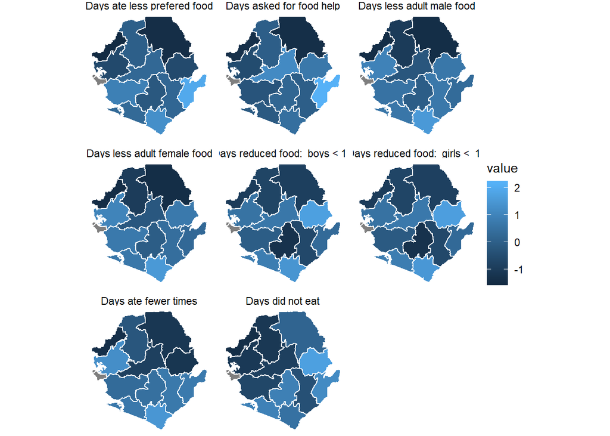

Distribution of standardized variables

### Definitions of measures

Data definitions

| Measure | Definition | Range |
| --- | --- | --- |
| Days ate less prefered food | Days of past 7 where household ate “less preferred foods” | 0 - 7 |
| Days asked for food help | Days of past 7 where household asked for help from relatives or friends for food | 0 - 7 |
| Days less adult male food | Days of past 7 where household reduced portions served per meal for adult males | 0 - 7 |
| Days less adult female food | Days of past 7 where household reduced portions served per meal for adult females | 0 - 7 |
| Days reduced food: boys < 10 | Days of past 7 where household reduced portions served per meal for boys under age 10 | 0 - 7 |
| Days reduced food: girls < 10 | Days of past 7 where household reduced portions/quantities served per meal for girls under age 10 | 0 - 7 |
| Days ate fewer times | Days of past 7 where household ate fewer times per day than normal for this time of year | 0 - 7 |
| Days did not eat | Days of past 7 where household spent whole day without eating | 0 - 7 |

## farming

### Time trends

#### National aggregates

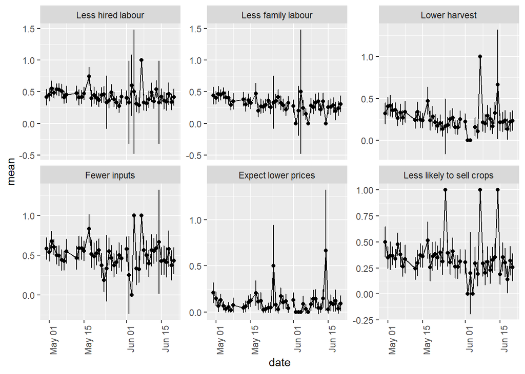

Average responses for a given day (dot) with 95% confidence intervals (whiskers)

#### Broken down by District

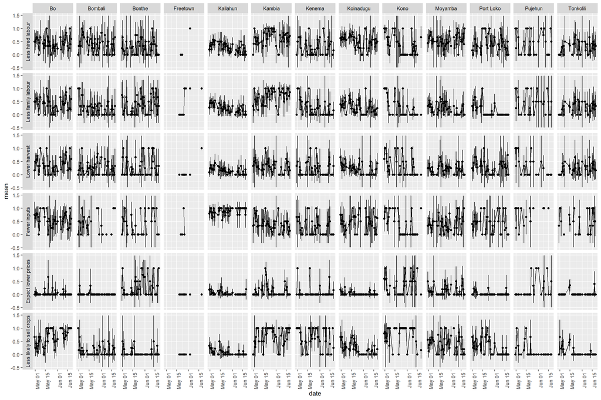

Disaggregated average responses for a given day (dot) with 95% confidence intervals (whiskers)

### Current averages

Mean responses in each District (most recent date)

| District | Date | Less hired labour | Less family labour | Fewer inputs | Lower harvest | Expect lower prices | Less likely to sell crops |
| --- | --- | --- | --- | --- | --- | --- | --- |
| Bo | 2020-05-21 | 0.45 | 0.40 | 0.57 | 0.38 | 0.04 | 0.60 |
| Bombali | 2020-05-23 | 0.42 | 0.25 | 0.44 | 0.28 | 0.01 | 0.13 |
| Bonthe | 2020-05-23 | 0.31 | 0.39 | 0.43 | 0.29 | 0.30 | 0.12 |
| Freetown | 2020-06-02 | 0.33 | 0.50 | 0.25 | 0.14 | 0.00 | 0.00 |
| Kailahun | 2020-05-20 | 0.30 | 0.28 | 0.86 | 0.16 | 0.05 | 0.09 |
| Kambia | 2020-05-21 | 0.63 | 0.66 | 0.38 | 0.31 | 0.12 | 0.69 |
| Kenema | 2020-05-22 | 0.33 | 0.30 | 0.33 | 0.23 | 0.05 | 0.54 |
| Koinadugu | 2020-05-21 | 0.52 | 0.29 | 0.48 | 0.24 | 0.04 | 0.25 |
| Kono | 2020-05-22 | 0.45 | 0.39 | 0.41 | 0.35 | 0.33 | 0.74 |
| Moyamba | 2020-05-21 | 0.54 | 0.24 | 0.37 | 0.21 | 0.14 | 0.43 |
| Port Loko | 2020-05-20 | 0.42 | 0.18 | 0.44 | 0.30 | 0.04 | 0.31 |
| Pujehun | 2020-05-21 | 0.45 | 0.43 | 0.69 | 0.33 | 0.17 | 0.22 |
| Tonkolili | 2020-05-24 | 0.29 | 0.26 | 0.48 | 0.22 | 0.05 | 0.15 |

### Maps

Showing most recent data available for each District.

Each map shows the *relative position* of each District — a score of 0 means average, and a score of 2 or -2 means far above or below average.

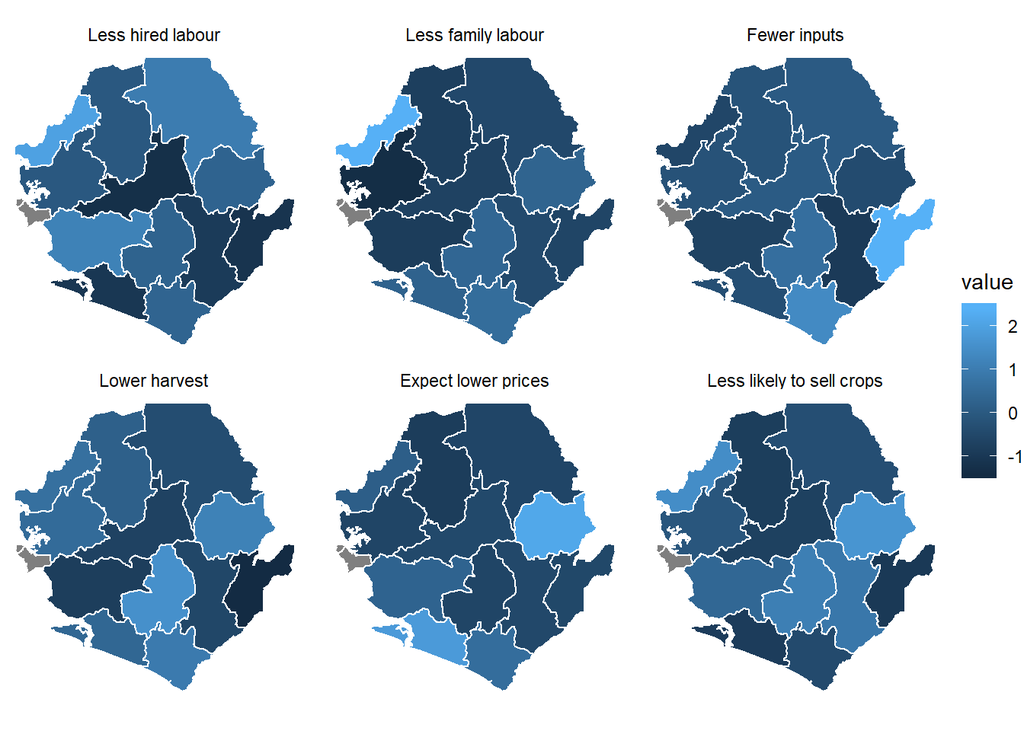

Distribution of standardized variables

### Definitions of measures

Data definitions

| Measure | Definition | Range |
| --- | --- | --- |
| Less hired labour | Relative to last year, fewer hired farm labour | 0 - 1 |
| Less family labour | Relative to last year, fewer family farm labour | 0 - 1 |
| Fewer inputs | Relative to last year, fewer farm inputs used | 0 - 1 |
| Lower harvest | Relative to last year, lower harvest | 0 - 1 |
| Expect lower prices | Relative to last year, expect lower prices | 0 - 1 |
| Less likely to sell crops | Relative to last year, less likely to sell crops | 0 - 1 |

## business

### Time trends

#### National aggregates

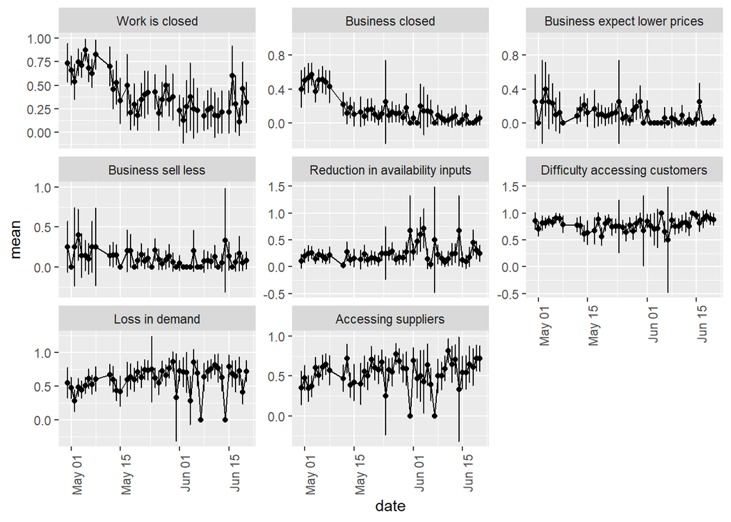

Average responses for a given day (dot) with 95% confidence intervals (whiskers)

#### Broken down by District

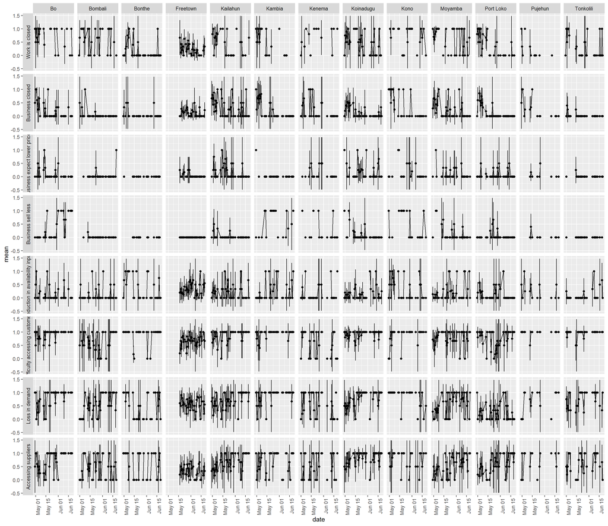

Disaggregated average responses for a given day (dot) with 95% confidence intervals (whiskers)

### Current averages

Mean responses in each District (most recent date)

| District | Date | Difficulty accessing customers | Loss in demand | Accessing suppliers | Reduction in availability inputs | Business closed | Work is closed | Business expect lower prices | Business sell less |
| --- | --- | --- | --- | --- | --- | --- | --- | --- | --- |
| Bo | 2020-05-21 | 0.86 | 0.76 | 0.67 | 0.14 | 0.25 | 0.65 | 0.13 | 0.30 |
| Bombali | 2020-05-23 | 0.60 | 0.56 | 0.47 | 0.10 | 0.05 | 0.66 | 0.03 | 0.02 |
| Bonthe | 2020-05-23 | 0.84 | 0.51 | 0.57 | 0.39 | 0.08 | 0.24 | 0.00 | 0.00 |
| Freetown | 2020-06-02 | 0.66 | 0.58 | 0.34 | 0.32 | 0.13 | 0.23 | 0.04 | 0.00 |
| Kailahun | 2020-05-20 | 0.85 | 0.66 | 0.61 | 0.21 | 0.34 | 0.53 | 0.20 | 0.05 |
| Kambia | 2020-05-21 | 0.88 | 0.77 | 0.64 | 0.21 | 0.29 | 0.63 | 0.02 | 0.54 |
| Kenema | 2020-05-22 | 0.66 | 0.56 | 0.48 | 0.16 | 0.22 | 0.62 | 0.18 | 0.24 |
| Koinadugu | 2020-05-21 | 0.90 | 0.72 | 0.81 | 0.12 | 0.19 | 0.52 | 0.17 | 0.08 |
| Kono | 2020-05-22 | 0.89 | 0.89 | 0.78 | 0.43 | 0.43 | 0.65 | 0.19 | 0.38 |
| Moyamba | 2020-05-21 | 0.78 | 0.55 | 0.49 | 0.13 | 0.26 | 0.70 | 0.12 | 0.15 |
| Port Loko | 2020-05-20 | 0.74 | 0.28 | 0.55 | 0.12 | 0.23 | 0.48 | 0.08 | 0.06 |
| Pujehun | 2020-05-21 | 0.93 | 0.67 | 0.73 | 0.30 | 0.27 | 0.32 | 0.10 | 0.11 |
| Tonkolili | 2020-05-24 | 0.93 | 0.68 | 0.58 | 0.10 | 0.05 | 0.36 | 0.02 | 0.00 |

### Maps

Showing most recent data available for each District.

Each map shows the *relative position* of each District — a score of 0 means average, and a score of 2 or -2 means far above or below average.

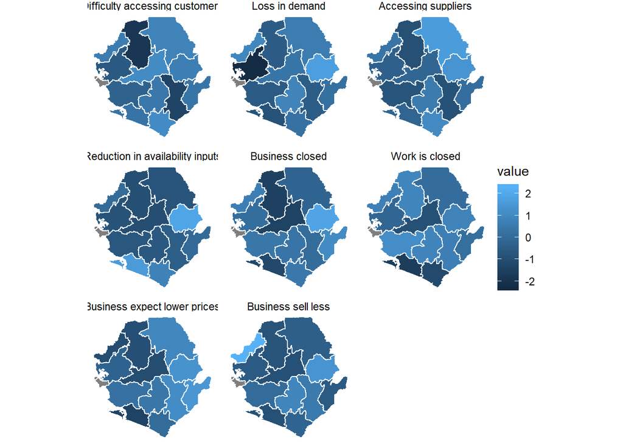

Distribution of standardized variables

### Definitions of measures

Data definitions

| Measure | Definition | Range |
| --- | --- | --- |
| Difficulty accessing customers | Share of businesses that have difficulty accessing customers because of government related restrictions. | 0 - 1 |
| Loss in demand | Share of businesses that have experienced a drop in demand because of government related restrictions. | 0 - 1 |
| Accessing suppliers | Share of businesses that have difficulties in accessing suppliers because of government related restrictions. | 0 - 1 |
| Reduction in availability inputs | Share of businesses that have experienced a reduction in the availability and/or price increases for main inputs because of government related restrictions. | 0 - 1 |
| Business closed | Share of self-employed respondents that report their business is closed | 0 - 1 |
| Work is closed | Share of employed respondents that report their work is closed | 0 - 1 |
| Business expect lower prices | Relative to last year, expect lower prices | 0 - 1 |
| Business sell less | Relative to last year, less likely to sell | 0 - 1 |

## social distancing

### Time trends

#### National aggregates

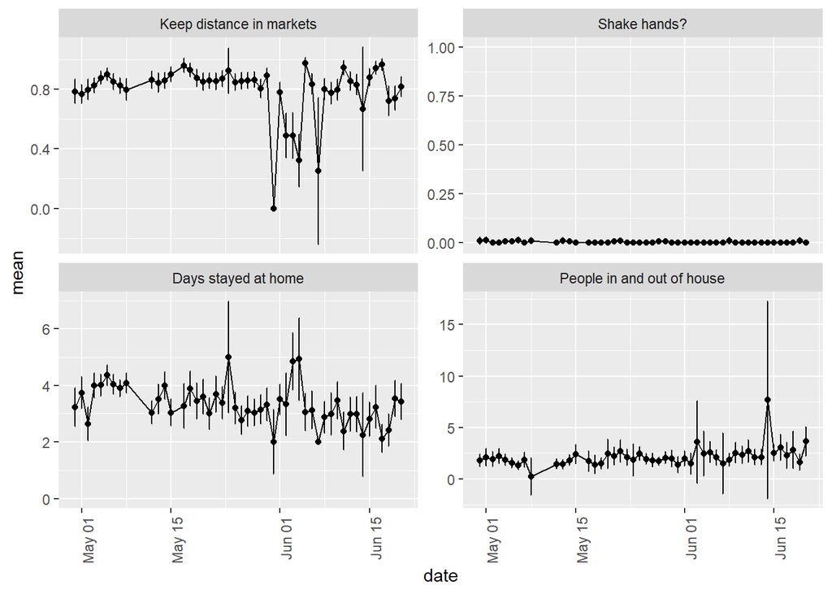

Average responses for a given day (dot) with 95% confidence intervals (whiskers)

#### Broken down by District

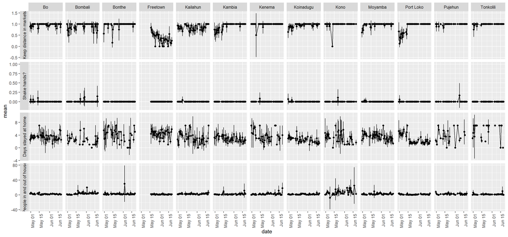

Disaggregated average responses for a given day (dot) with 95% confidence intervals (whiskers)

### Current averages

Mean responses in each District (most recent date)

| District | Date | People in and out of house | Days stayed at home | Shake hands? | Keep distance in markets |
| --- | --- | --- | --- | --- | --- |
| Bo | 2020-05-21 | 2.14 | 3.21 | 0.01 | 0.95 |
| Bombali | 2020-05-23 | 3.25 | 2.67 | 0.01 | 0.89 |
| Bonthe | 2020-05-23 | 2.21 | 4.37 | 0.00 | 0.93 |
| Freetown | 2020-06-02 | 1.04 | 4.48 | 0.00 | 0.41 |
| Kailahun | 2020-05-20 | 2.62 | 3.40 | 0.00 | 0.82 |
| Kambia | 2020-05-21 | 1.54 | 2.80 | 0.00 | 0.87 |
| Kenema | 2020-05-22 | 2.71 | 3.55 | 0.00 | 0.99 |
| Koinadugu | 2020-05-21 | 1.47 | 2.75 | 0.00 | 0.93 |
| Kono | 2020-05-22 | 6.39 | 3.29 | 0.00 | 0.99 |
| Moyamba | 2020-05-21 | 2.16 | 3.70 | 0.00 | 0.95 |
| Port Loko | 2020-05-20 | 0.94 | 2.71 | 0.00 | 0.78 |
| Pujehun | 2020-05-21 | 2.41 | 3.78 | 0.01 | 0.97 |
| Tonkolili | 2020-05-24 | 1.30 | 4.35 | 0.00 | 0.99 |

### Maps

Showing most recent data available for each District.

Each map shows the *relative position* of each District — a score of 0 means average, and a score of 2 or -2 means far above or below average.

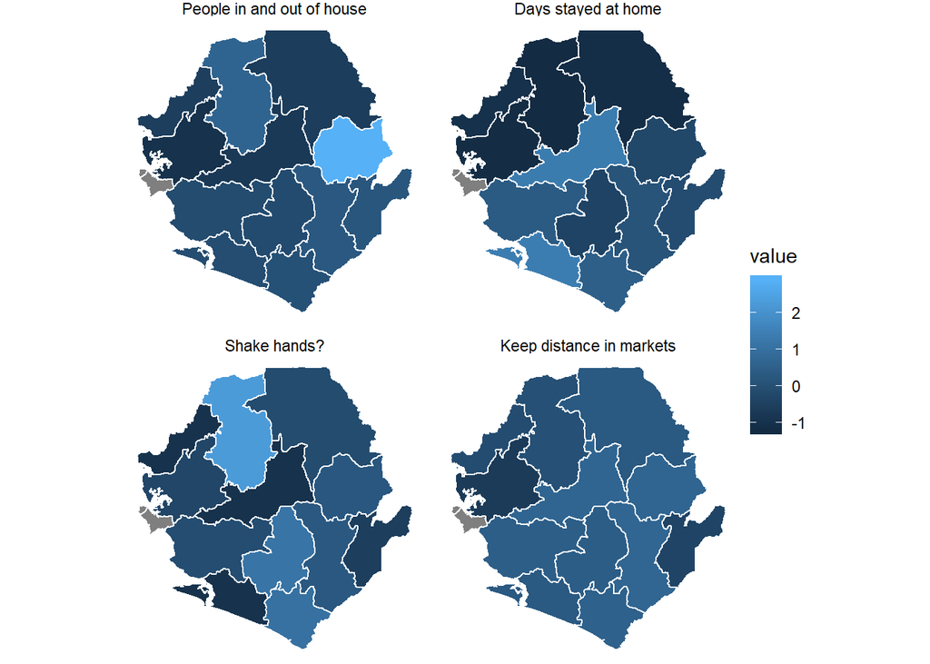

Distribution of standardized variables

### Definitions of measures

Data definitions

[output not shown]

## covid

### Time trends

#### National aggregates

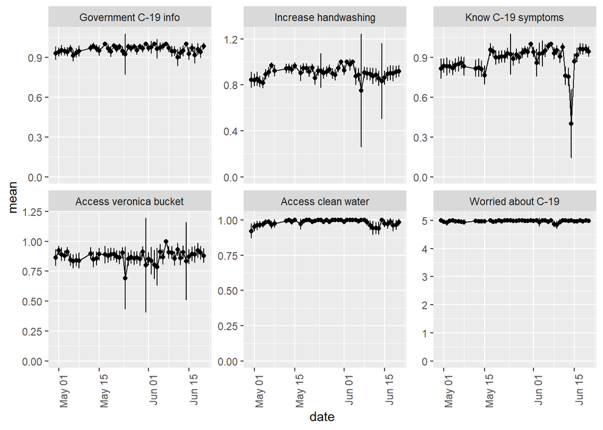

Average responses for a given day (dot) with 95% confidence intervals (whiskers)

#### Broken down by District

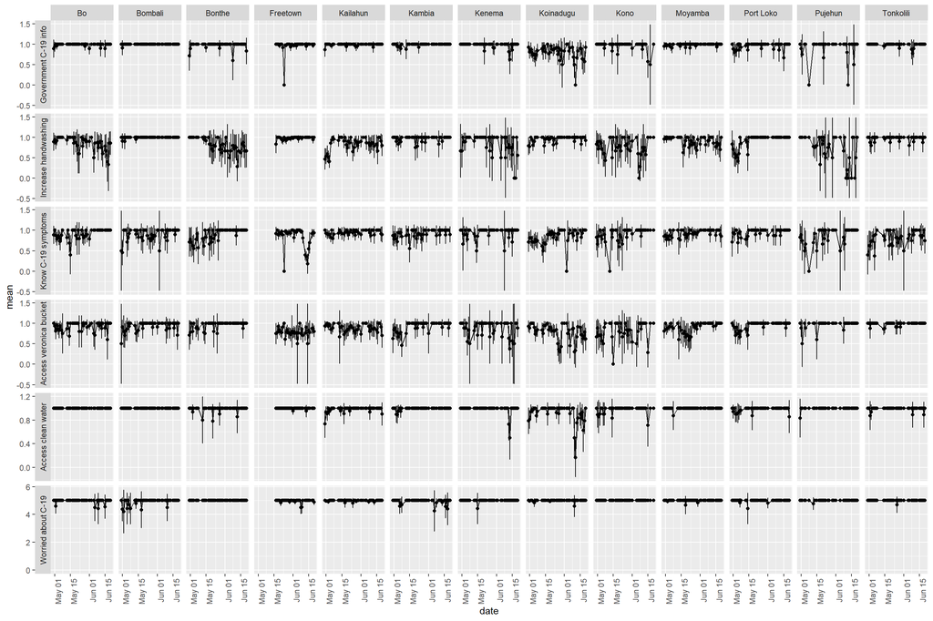

Disaggregated average responses for a given day (dot) with 95% confidence intervals (whiskers)

### Current averages

Mean responses in each District (most recent date)

| District | Date | Government C-19 info | Know C-19 symptoms | Access veronica bucket | Access clean water | Increase handwashing | Worried about C-19 |
| --- | --- | --- | --- | --- | --- | --- | --- |
| Bo | 2020-05-21 | 0.98 | 0.89 | 0.91 | 1.00 | 0.88 | 4.96 |
| Bombali | 2020-05-23 | 1.00 | 0.90 | 0.92 | 1.00 | 0.99 | 4.90 |
| Bonthe | 2020-05-23 | 0.97 | 0.87 | 0.94 | 0.98 | 0.83 | 5.00 |
| Freetown | 2020-06-02 | 0.98 | 0.85 | 0.79 | 1.00 | 0.97 | 4.94 |
| Kailahun | 2020-05-20 | 0.99 | 0.93 | 0.88 | 0.98 | 0.81 | 4.98 |
| Kambia | 2020-05-21 | 0.98 | 0.90 | 0.89 | 0.98 | 0.96 | 4.94 |
| Kenema | 2020-05-22 | 0.96 | 0.91 | 0.84 | 0.97 | 0.88 | 4.98 |
| Koinadugu | 2020-05-21 | 0.81 | 0.83 | 0.81 | 0.93 | 0.94 | 4.98 |
| Kono | 2020-05-22 | 0.96 | 0.90 | 0.79 | 0.97 | 0.76 | 5.00 |
| Moyamba | 2020-05-21 | 0.98 | 0.91 | 0.90 | 1.00 | 0.91 | 4.98 |
| Port Loko | 2020-05-20 | 0.95 | 0.92 | 0.91 | 0.98 | 0.88 | 4.97 |
| Pujehun | 2020-05-21 | 0.95 | 0.83 | 0.95 | 0.99 | 0.78 | 4.98 |
| Tonkolili | 2020-05-24 | 0.98 | 0.82 | 0.97 | 0.99 | 0.97 | 4.99 |

### Maps

Showing most recent data available for each District.

Each map shows the *relative position* of each District — a score of 0 means average, and a score of 2 or -2 means far above or below average.

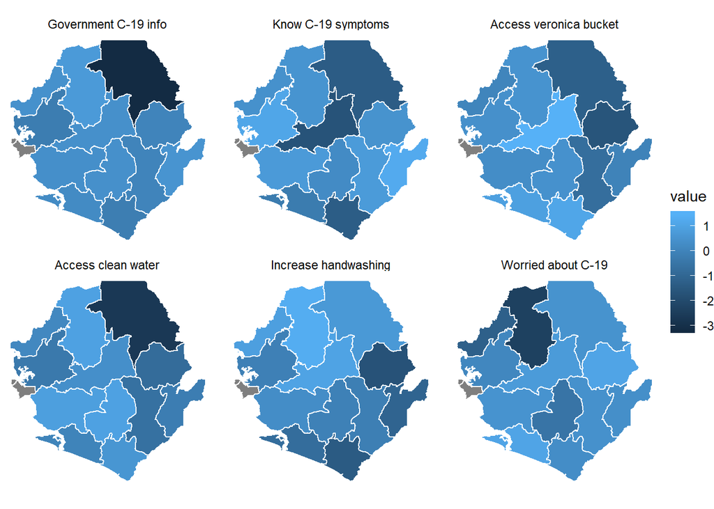

Distribution of standardized variables

### Definitions of measures

Data definitions

| Measure | Definition | Range |
| --- | --- | --- |
| Government C-19 info | Share of respondents who receive information about C-19 from the government | 0 - 1 |
| Know C-19 symptoms | Share of respondents that know any signs and symptoms of C-19 | 0 - 1 |
| Access veronica bucket | Share of respondents that have access to a veronica bucket | 0 - 1 |
| Access clean water | Share of respondents that have access to clean water to wash your hands | 0 - 1 |
| Increase handwashing | Share of respondents that report they increased handwashing in the past 7 days | 0 - 1 |
| Worried about C-19 | How worried is respondent about C-19, range: 1=not at all, 5=very worried | 0 - 5 |

## illness

### Time trends

#### National aggregates

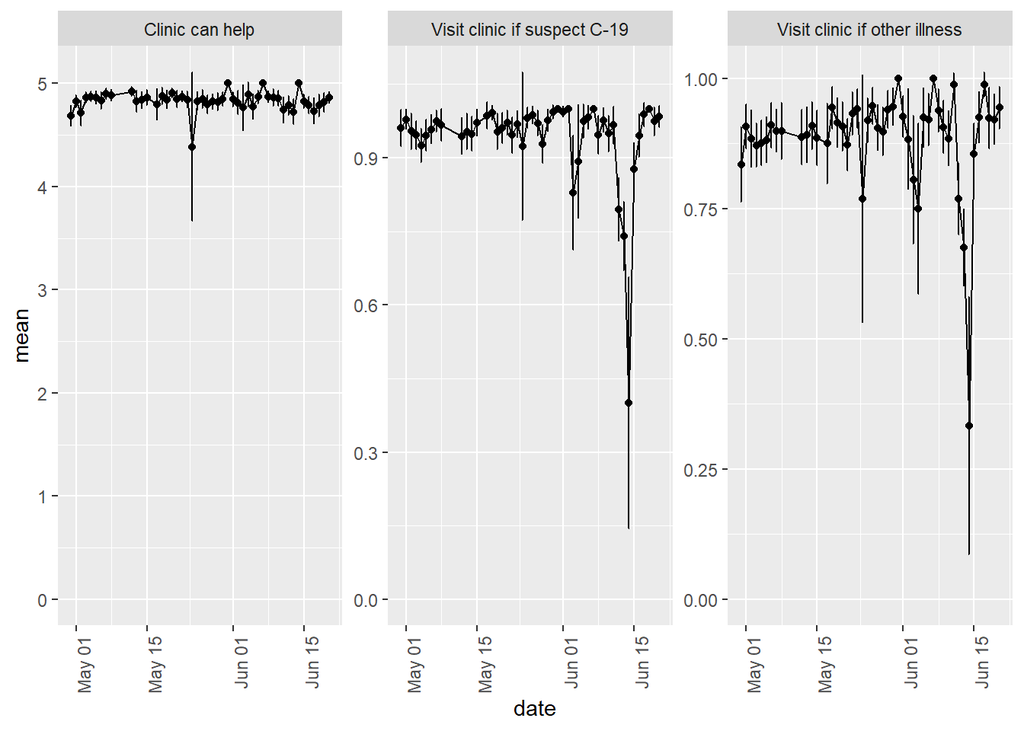

Average responses for a given day (dot) with 95% confidence intervals (whiskers)

#### Broken down by District

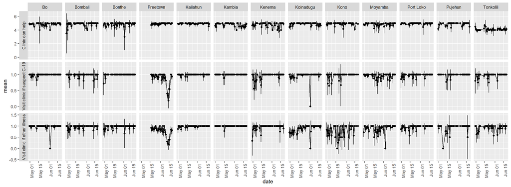

Disaggregated average responses for a given day (dot) with 95% confidence intervals (whiskers)

### Current averages

Mean responses in each District (most recent date)

| District | Date | Visit clinic if suspect C-19 | Visit clinic if other illness | Clinic can help |
| --- | --- | --- | --- | --- |
| Bo | 2020-05-21 | 0.98 | 0.98 | 4.88 |
| Bombali | 2020-05-23 | 0.97 | 0.95 | 4.88 |
| Bonthe | 2020-05-23 | 0.99 | 0.95 | 4.83 |
| Freetown | 2020-06-02 | 0.84 | 0.73 | 4.91 |
| Kailahun | 2020-05-20 | 0.99 | 0.98 | 4.94 |
| Kambia | 2020-05-21 | 0.99 | 0.99 | 4.82 |
| Kenema | 2020-05-22 | 0.91 | 0.94 | 4.77 |
| Koinadugu | 2020-05-21 | 0.97 | 0.85 | 4.90 |
| Kono | 2020-05-22 | 0.95 | 0.77 | 4.89 |
| Moyamba | 2020-05-21 | 0.95 | 0.90 | 4.86 |
| Port Loko | 2020-05-20 | 0.97 | 0.94 | 4.93 |
| Pujehun | 2020-05-21 | 0.97 | 0.92 | 4.81 |
| Tonkolili | 2020-05-24 | 0.97 | 0.90 | 4.11 |

### Maps

Showing most recent data available for each District.

Each map shows the *relative position* of each District — a score of 0 means average, and a score of 2 or -2 means far above or below average.

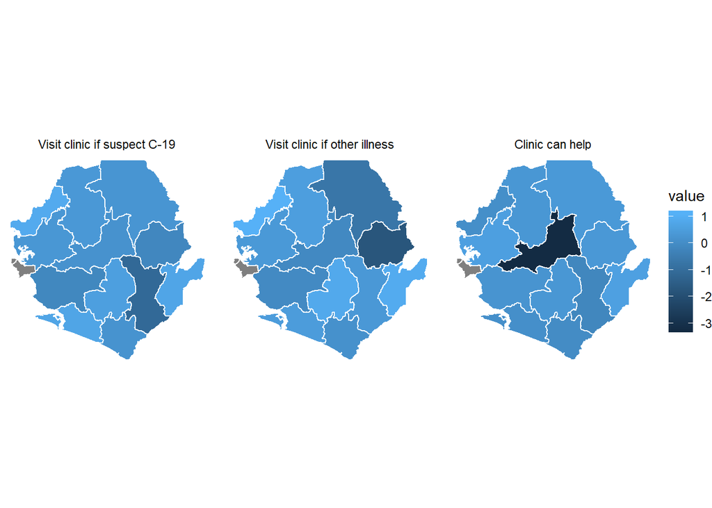

Distribution of standardized variables

### Definitions of measures

Data definitions

| Measure | Definition | Range |
| --- | --- | --- |
| Visit clinic if suspect C-19 | Share of respondents that would visit clinic if showing symptoms of C-19 | 0 - 1 |
| Visit clinic if other illness | Share of respondents that would visit clinic if sick with other illnesses | 0 - 1 |
| Clinic can help | How confident respondents feel clinic can help, range: 1=not at all, 5=very confident | 0 - 5 |

## All Data

### Browse data

|  | id | date | n | district | market_open | market_day | rice_avail | cass_avail | fish_avail | oil_avail | mag_avail | rice_now_w | cass_bunch_price_w | fish_buy_bundle_w | oil_now_w | mag_now_w | less_prefer | ask_help | reduce_male | reduce_female | reduce_boy | reduce_girl | eat_less | no_eat | farm_l_hire | farm_l_time | inputs_l | harv_l | price_l | … |
| --- | --- | --- | --- | --- | --- | --- | --- | --- | --- | --- | --- | --- | --- | --- | --- | --- | --- | --- | --- | --- | --- | --- | --- | --- | --- | --- | --- | --- | --- | --- |
| 1 | Bo | 2020-04-30 |  | 31 | 1 | 5.889 | 1 | 0.778 | 1 | 1 | 1 | 1766.667 | 3214.286 | 435.902 | 2188.889 | 500 | 2.222 | 1.056 | 1.556 | 1.389 | 0.111 | 0.111 | 1.444 | 0.389 | 0.5 | 0.5 | 0.75 | 0.167 | 0 | … |
| 2 | Bo | 2020-05-01 |  | 31 | 0.938 | 6.267 | 1 | 0.867 | 1 | 1 | 1 | 1886.667 | 3636.364 | 417.397 | 2320 | 500 | 1.969 | 1.25 | 1.5 | 1.781 | 0.344 | 0.344 | 1.25 | 0.281 | 0.5 | 0.5 | 0.625 | 0.5 | 0.1 | … |
| 3 | Bo | 2020-05-02 |  | 31 | 0.938 | 5.933 | 1 | 0.933 | 1 | 1 | 1 | 1833.333 | 4041.667 | 1081.03 | 2842.857 | 500 | 2.312 | 1.688 | 2.188 | 1.938 | 0.344 | 0.125 | 2.062 | 0.938 | 0.583 | 0.5 | 0.727 | 0.455 | 0 | … |
| 4 | Bo | 2020-05-03 |  | 31 | 0.958 | 6 | 1 | 0.696 | 1 | 1 | 1 | 1860.87 | 3766.667 | 3100.078 | 2369.565 | 500 | 1.521 | 1.229 | 1.854 | 2.042 | 0.375 | 0.271 | 1.438 | 0.438 | 0.667 | 0.625 | 0.8 | 0.562 | 0.067 | … |
| 5 | Bo | 2020-05-04 |  | 31 | 1 | 6.182 | 1 | 0.636 | 0.955 | 1 | 1 | 1809.091 | 5863.636 | 619.828 | 2272.727 | 500 | 1.81 | 1.214 | 2.023 | 1.864 | 0.409 | 0.25 | 1.477 | 0.432 | 0.643 | 0.571 | 0.778 | 0.714 | 0 | … |
| 6 | Bo | 2020-05-05 |  | 31 | 1 | 5.882 | 1 | 0.647 | 0.941 | 1 | 1 | 1817.647 | 5409.091 | 6536.688 | 2131.25 | 500 | 2.235 | 1.265 | 2.441 | 2.118 | 0.735 | 0.971 | 1.824 | 0.324 | 0.556 | 0.4 | 0.667 | 0.333 | 0 | … |
| 7 | Bo | 2020-05-06 |  | 31 | 1 | 6.067 | 1 | 0.667 | 0.667 | 1 | 1 | 1878.571 | 7857.143 | 6539.557 | 2300 | 500 | 2.467 | 1.633 | 2.9 | 2.6 | 1.4 | 1.333 | 2.2 | 1.033 | 0 | 0 | 0 | 0 | 0 | … |
| 8 | Bo | 2020-05-07 |  | 31 | 1 | 6 | 1 | 0.706 | 0.706 | 0.882 | 1 | 1794.118 | 3727.273 | 294.887 | 2433.333 | 500 | 2.059 | 1.353 | 2.294 | 2.676 | 1.471 | 1.656 | 2.294 | 0.324 | 0.455 | 0.5 | 0.5 | 0.333 | 0 | … |
| 9 | Bo | 2020-05-08 |  | 31 | 1 | 6.25 | 1 | 0.25 | 0.5 | 1 | 1 | 1925 | 2500 | 251.734 | 2375 | 500 | 1.875 | 1.25 | 4.125 | 3 | 2.375 | 2.375 | 4.125 | 0.625 | 0.667 | 0.667 | 1 | 1 | 0 | … |
| 10 | Bo | 2020-05-12 |  | 31 | 0.933 | 6.214 | 1 | 0.643 | 0.714 | 1 | 1 | 1764.286 | 4785.714 | 877.995 | 2250 | 500 | 1.733 | 0.867 | 1.867 | 1.867 | 0.867 | 0.467 | 2.133 | 0.2 | 0.429 | 0.429 | 1 | 0.429 | 0 | … |

[output cut: 516 more lines]

### Data summaries

**Technical**: Summary measures on all data.

| variable | Bo | Bombali | Bonthe | Freetown | Kailahun | Kambia | Kenema | Koinadugu | Kono | Moyamba | Port Loko | Pujehun | Tonkolili | Overall |
| --- | --- | --- | --- | --- | --- | --- | --- | --- | --- | --- | --- | --- | --- | --- |
| N | 427 | 369 | 336 | 933 | 734 | 395 | 237 | 702 | 243 | 659 | 451 | 148 | 373 | 6007 |
| district | 31 | 21 | 32 | 42 | 11 | 22 | 12 | 23 | 13 | 33 | 24 | 34 | 25 | 26.0971 |
| market_open | 0.9694 | 0.9538 | 0.9582 | 0.8014 | 0.7735 | 0.9061 | 0.9619 | 0.9712 | 0.8354 | 0.9453 | 0.9417 | 0.9521 | 0.9598 | 0.904 |
| market_day | 6.0995 | 6.7407 | 6.7445 | 6.7477 | 6.5062 | 6.6106 | 6.0264 | 6.3896 | 5.8079 | 6.1768 | 6.4167 | 6.6115 | 6.3101 | 6.4238 |
| rice_avail | 1 | 0.9915 | 0.9907 | 1 | 0.8601 | 0.9944 | 0.7621 | 0.8846 | 0.7304 | 0.8915 | 0.9786 | 0.8633 | 0.9721 | 0.9278 |
| cass_avail | 0.8155 | 0.6239 | 0.9252 | 0.7432 | 0.787 | 0.1681 | 0.6476 | 0.2263 | 0.299 | 0.5008 | 0.6643 | 0.7698 | 0.7318 | 0.5987 |
| fish_avail | 0.9175 | 0.906 | 0.9657 | 0.9775 | 0.7281 | 0.9468 | 0.5683 | 0.5222 | 0.4314 | 0.6459 | 0.8952 | 0.7698 | 0.9162 | 0.7869 |
| oil_avail | 0.9927 | 1 | 0.9875 | 1 | 0.9205 | 1 | 0.9295 | 0.8861 | 0.7549 | 0.949 | 0.9857 | 0.8633 | 0.9832 | 0.9512 |
| mag_avail | 1 | 1 | 0.9969 | 1 | 0.8585 | 1 | 0.9559 | 0.8772 | 0.7304 | 0.9394 | 0.9786 | 0.8633 | 0.986 | 0.9426 |
| rice_now_w | 1891.0097 | 2026.5539 | 1961.039 | 1803.8219 | 2248.4323 | 1921.4944 | 1881.3953 | 1939.991 | 1917.4497 | 1979.9642 | 1955.3659 | 2205.8333 | 1961.5497 | 1969.5575 |

[output cut: 39 more lines]

Notes

[^1]: Niccolo Meriggi (IGC Sierra Leone), Macartan Humphreys (WZB Berlin and Columbia Univerisity), Abou Bakarr Kamara (IGC Sierra Leone), Matthew Krupoff (Y-Rise), Madison Levine (Wageningen U), Mushfiq Mobarak (Yale University), Wilson Prichard (U Toronto), Ashwini Shridhar (Wageningen U), Peter van der Windt (NYU AD), Maarten Voors (Wageningen University). Feedback welcome! Please get in touch via email at tracking.corona.sl@gmail.com.